# An Introduction to the Bioeconomy

HEKA22—Lecture 8

Jonas Kreutzer

2026-05-26

# Learning Objectives

**By the end of today’s lecture you should be able to:**

1. Be able to contrast the concepts bioeconomy and bioeconomics
2. Know the most important sources of biomass and their limitations
3. Describe the role of innovation in the bioeconomy transition
4. Critically evaluate sustainability claims made about the bioeconomy

# What is the bioeconomy?

## Co-opting Georgescu-Roegen (1975)’s bioeconomics

## Bioeconomy visions

### Bioresource

[figure not shown]

### Biotechnology

[figure not shown]

### Bioecology

[figure not shown]

Classification based on Bugge et al. (2016) and Vivien et al. (2019)

# Innovation and Change

## Definition of innovation

> “An innovation is anew or improved product or process (or combination thereof) that differs significantly from the unit’s previous products or processes and that has beenmade available to potential users (product) or brought into use by the unit (process).”

OECD and Eurostat (2018, 20)

## Kondratieff Cycles

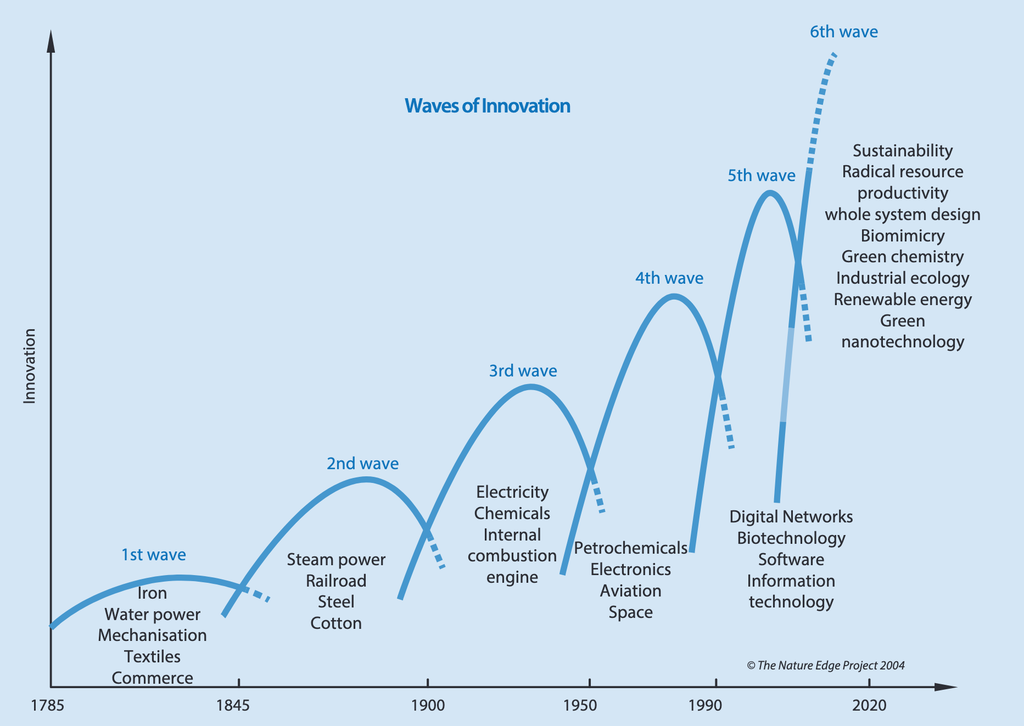

Figure 1: Kondratieff Cycles copied from Pyka (2020)

## Swedish forest-based bioeconomy innovations

[figure not shown]

Figure 2: Counts of innovation classification by Bioeconomy Vision Category (Kreutzer 2026)

# The political economy of bioeconomies

## Sources of biomass

**Agriculture**

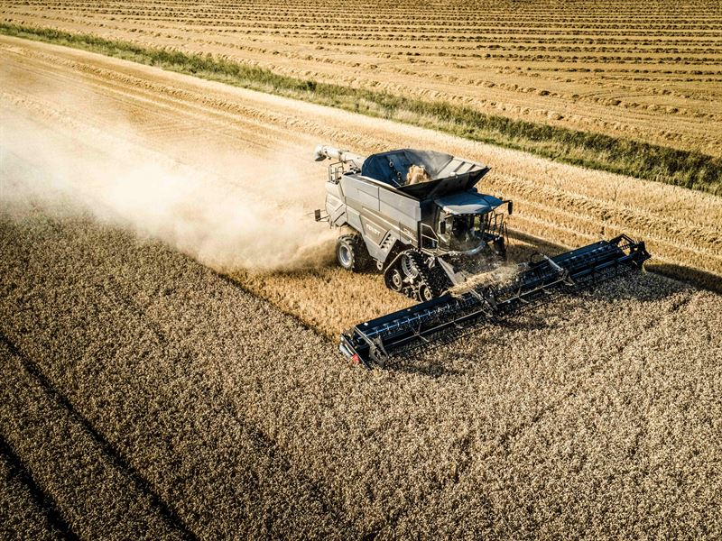

**Forestry**

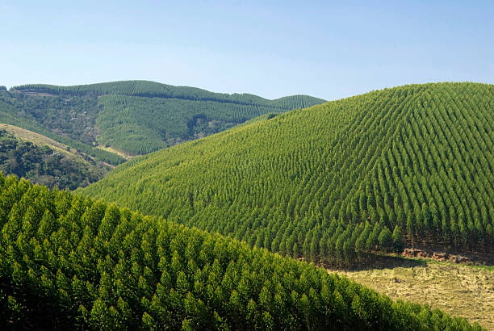

**Aquaculture**

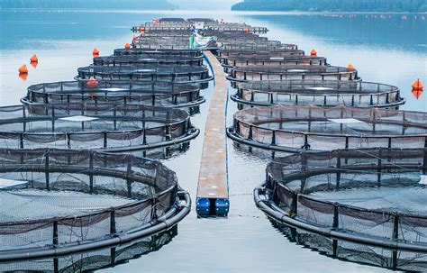

**Waste**

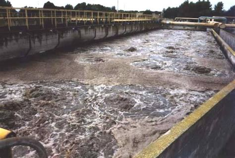

## Global North-South Dynamics

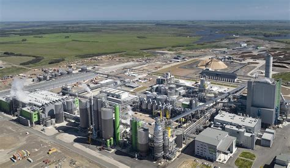

Figure 3: Paso de los Toros, Uruguay’s largest pulp mill

[figure not shown]

Figure 4: Protest against Uruguay River destruction

## Alternative low-intensity uses

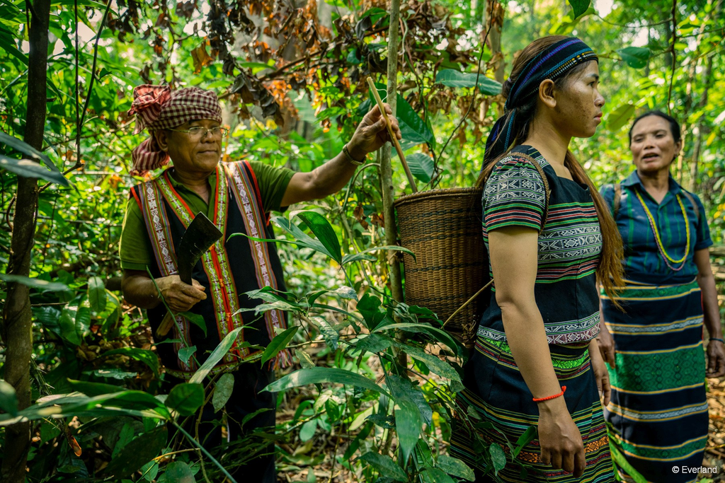

Figure 5: Non Timber Forest Product use in Indonesia

## Checking in on Learning Objectives

**By the end of this course you should:**

Demonstrate the ability to independently apply anthropological, historical, sociological, and economic perspectives to environmental issues,

- demonstrate the ability to convey in-depth knowledge of human ecology in both spoken and written communication,
- demonstrate the ability to conduct subject-related information searches, evaluate information, and master reference management.
- demonstrate the ability to engage in informed discussion of the relationship between environmental problems and economic growth,

## References

Bugge, Markus M., Teis Hansen, and Antje Klitkou. 2016. “What Is the Bioeconomy? A Review of the Literature.” *Sustainability* 8 (7): 691. https://doi.org/10.3390/su8070691.

Georgescu-Roegen, Nicholas. 1975. “Energy and Economic Myths.” *Southern Economic Journal* 41 (3): 347. https://doi.org/10.2307/1056148.

Kreutzer, Philipp Jonas. 2026. “Consolidating Rather Than Guiding Bioeconomy Visions Center on Existing Technological Trajectories in Swedish Forestry.” Unpublished manuscript.

OECD, and Eurostat. 2018. *Oslo Manual 2018: Guidelines for Collecting, Reporting and Using Data on Innovation, 4th Edition*. The Measurement of Scientific, Technological and Innovation Activities. OECD. https://doi.org/10.1787/9789264304604-en.

Pyka, Andreas. 2020. “The Bioeconomy from the Point of View of Innovation Economics.” In *Bioeconomy for Beginners*, edited by Joachim Pietzsch. Springer Berlin Heidelberg. https://doi.org/10.1007/978-3-662-60390-1.

Vivien, F. -D., M. Nieddu, N. Befort, R. Debref, and M. Giampietro. 2019. “The Hijacking of the Bioeconomy.” *Ecological Economics* 159 (May): 189–97. https://doi.org/10.1016/j.ecolecon.2019.01.027.